# Fitting structural mean models

Tom Palmer

20 March 2023

## Introduction

This is the code from the appendix of Clarke, et al., Estimating Structural Mean Models with Multiple Instrumental Variables Using the Generalised Method of Moments. Statistical Science, 2015, 30, 1, 96-177. https://dx.doi.org/10.1214/14-STS503

- Load R packages

```r
library(gmm)
library(ivtools)
library(logbin)
library(boot)
library(ivreg)
library(msm)
library(geeM)
library(geepack)
library(dplyr)
```

## Example data

Using the data from example 2 from the `ivtools::ivglm()` helpfile.

```r
set.seed(9)
n <- 1000
psi0 <- 0.5
psi1 <- 0.2
Z <- rbinom(n, 1, 0.5)
X <- rbinom(n, 1, 0.7 * Z + 0.2 * (1 - Z))
m0 <- plogis(1 + 0.8 * X - 0.39 * Z)
Y <- rbinom(n, 1, plogis(psi0 * X + log(m0 / (1 - m0))))
dat <- data.frame(Z, X, Y)
```

## Fitting Structural Mean Models

### Additive structural mean model: estimation of the causal risk difference

- Formula syntax

```r
asmm <- gmm(dat[, "Y"] ~ dat[, "X"], x = dat[, c("Z")], vcov = "iid")

# model summary
summary(asmm)
```

```
##
## Call:
## gmm(g = dat[, "Y"] ~ dat[, "X"], x = dat[, c("Z")], vcov = "iid")
##
##
## Method:  twoStep
##
## Coefficients:
##              Estimate     Std. Error   t value      Pr(>|t|)
## (Intercept)   7.2766e-01   2.5120e-02   2.8967e+01  1.7035e-184
## dat[, "X"]    1.0647e-01   4.7387e-02   2.2469e+00   2.4646e-02
##
## J-Test: degrees of freedom is 0
##                 J-test                P-value
## Test E(g)=0:    2.80175043845722e-30  *******
```

```r
# estimates with 95% CIs
cbind(coef(asmm), confint(asmm)$test)
```

```
##                            0.025     0.975
## (Intercept) 0.7276608 0.67842617 0.7768953
## dat[, "X"]  0.1064741 0.01359713 0.1993511
```

```r
# over-identification test
# specTest(asmm)
```

- Alternative function syntax

```r
asmmMoments <- function(theta, x) {
  # extract variables from x
  Y <- x[, "Y"]
  X <- x[, "X"]
  Z1 <- x[, "Z"]
  # moments
  m1 <- (Y - theta[1] - theta[2] * X)
  m2 <- (Y - theta[1] - theta[2] * X) * Z1
  return(cbind(m1, m2))
}

asmm2 <- gmm(asmmMoments, x = dat, t0 = c(0, 0), vcov = "iid")

# estimates
summary(asmm2)
```

```
##
## Call:
## gmm(g = asmmMoments, x = dat, t0 = c(0, 0), vcov = "iid")
##
##
## Method:  twoStep
##
## Coefficients:
##           Estimate     Std. Error   t value      Pr(>|t|)
## Theta[1]   7.2756e-01   2.6316e-02   2.7647e+01  3.0543e-168
## Theta[2]   1.0670e-01   4.7458e-02   2.2483e+00   2.4559e-02
##
## J-Test: degrees of freedom is 0
##                 J-test                P-value
## Test E(g)=0:    1.13944836048446e-06  *******
##
## #############
## Information related to the numerical optimization
## Convergence code =  0
## Function eval. =  59
## Gradian eval. =  NA
```

```r
cbind(coef(asmm2), confint(asmm2)$test)
```

```
##                         0.025     0.975
## Theta[1] 0.7275645 0.67598519 0.7791438
## Theta[2] 0.1066979 0.01368244 0.1997133
```

```r
# over-identification test
# specTest(asmm2)
```

- TSLS fit

```r
asmmtsls <- ivreg(Y ~ X | Z, data = dat)
summary(asmmtsls)
```

```
##
## Call:
## ivreg(formula = Y ~ X | Z, data = dat)
##
## Residuals:
##     Min      1Q  Median      3Q     Max
## -0.8341  0.1659  0.1659  0.2723  0.2723
##
## Coefficients:
##             Estimate Std. Error t value Pr(>|t|)
## (Intercept)  0.72766    0.02515  28.938   <2e-16 ***
## X            0.10647    0.04743   2.245    0.025 *
##
## Diagnostic tests:
##                  df1 df2 statistic p-value
## Weak instruments   1 998   432.087  <2e-16 ***
## Wu-Hausman         1 997     1.844   0.175
## Sargan             0  NA        NA      NA
## ---
## Signif. codes:  0 '***' 0.001 '**' 0.01 '*' 0.05 '.' 0.1 ' ' 1
##
## Residual standard error: 0.4105 on 998 degrees of freedom
## Multiple R-Squared: 0.03246, Adjusted R-squared: 0.03149
## Wald test: 5.038 on 1 and 998 DF,  p-value: 0.02501
```

```r
cbind(coef(asmmtsls), confint(asmmtsls))
```

```
##                            2.5 %    97.5 %
## (Intercept) 0.7276608 0.67831702 0.7770045
## X           0.1064741 0.01339123 0.1995570
```

#### Comparison fits

##### Two-stage residual inclusion

- TSRI estimated using GMM with additive error

```r
tsriIdentAddMoments <- function(theta, x) {
  # extract variables from x
  Y <- x[, "Y"]
  X <- x[, "X"]
  Z1 <- x[, "Z"]
  # generate first stage residuals
  stage1 <- lm(X ~ Z1)
  res <- residuals(stage1)
  # moments
  a1 <- (X - theta[1] - Z1 * theta[2])
  a2 <- (X - theta[1] - Z1 * theta[2]) * Z1
  m1 <- (Y - (theta[3] + X * theta[4] + theta[5] * (X - theta[1] - Z1 * theta[2])))
  m2 <- (Y - (theta[3] + X * theta[4] + theta[5] * (X - theta[1] - Z1 * theta[2]))) * X
  m3 <- (Y - (theta[3] + X * theta[4] + theta[5] * (X - theta[1] - Z1 * theta[2]))) * res
  return(cbind(a1, a2, m1, m2, m3))
}

tsrigmmident <- gmm(tsriIdentAddMoments, x = dat, t0 = rep(0, 5), vcov = "iid")

# estimates
summary(tsrigmmident)
```

```
##
## Call:
## gmm(g = tsriIdentAddMoments, x = dat, t0 = rep(0, 5), vcov = "iid")
##
##
## Method:  twoStep
##
## Coefficients:
##           Estimate     Std. Error   t value      Pr(>|t|)
## Theta[1]   1.7670e-01   1.7169e-02   1.0292e+01   7.6811e-25
## Theta[2]   5.4703e-01   2.6249e-02   2.0840e+01   1.8884e-96
## Theta[3]   7.2672e-01   2.6329e-02   2.7602e+01  1.0592e-167
## Theta[4]   1.0843e-01   4.7485e-02   2.2834e+00   2.2405e-02
## Theta[5]   7.4632e-02   5.8845e-02   1.2683e+00   2.0470e-01
##
## J-Test: degrees of freedom is 0
##                 J-test                P-value
## Test E(g)=0:    1.76779675216641e-05  *******
##
## #############
## Information related to the numerical optimization
## Convergence code =  1
## Function eval. =  502
## Gradian eval. =  NA
```

```r
# causal risk difference
cbind(coef(tsrigmmident), confint(tsrigmmident)$test)[3:5, ]
```

```
##                           0.025     0.975
## Theta[3] 0.72672203  0.67511851 0.7783255
## Theta[4] 0.10842753  0.01535958 0.2014955
## Theta[5] 0.07463223 -0.04070184 0.1899663
```

##### G-estimation

```r
fitZ.L <- glm(Z ~ 1, data = dat)
fitY.LZX <- glm(Y ~ X + Z + X * Z, family = "binomial", data = dat)
fitIdentGest <-
  ivglm(
    estmethod = "g",
    X = "X",
    fitZ.L = fitZ.L,
    fitY.LZX = fitY.LZX,
    data = dat,
    link = "identity",
    Y = "Y"
  )

# model summary
summary(fitIdentGest)
```

```
##
## Call:
## ivglm(estmethod = "g", X = "X", Y = "Y", fitZ.L = fitZ.L, fitY.LZX = fitY.LZX,
##     data = dat, link = "identity")
##
## Coefficients:
##   Estimate Std. Error z value Pr(>|z|)
## X  0.10647    0.04748   2.242   0.0249 *
## ---
## Signif. codes:  0 '***' 0.001 '**' 0.01 '*' 0.05 '.' 0.1 ' ' 1
```

```r
# estimates and CIs
cbind(fitIdentGest$est, confint(fitIdentGest))
```

```
##                  2.5 %    97.5 %
## X 0.1064741 0.01341052 0.1995377
```

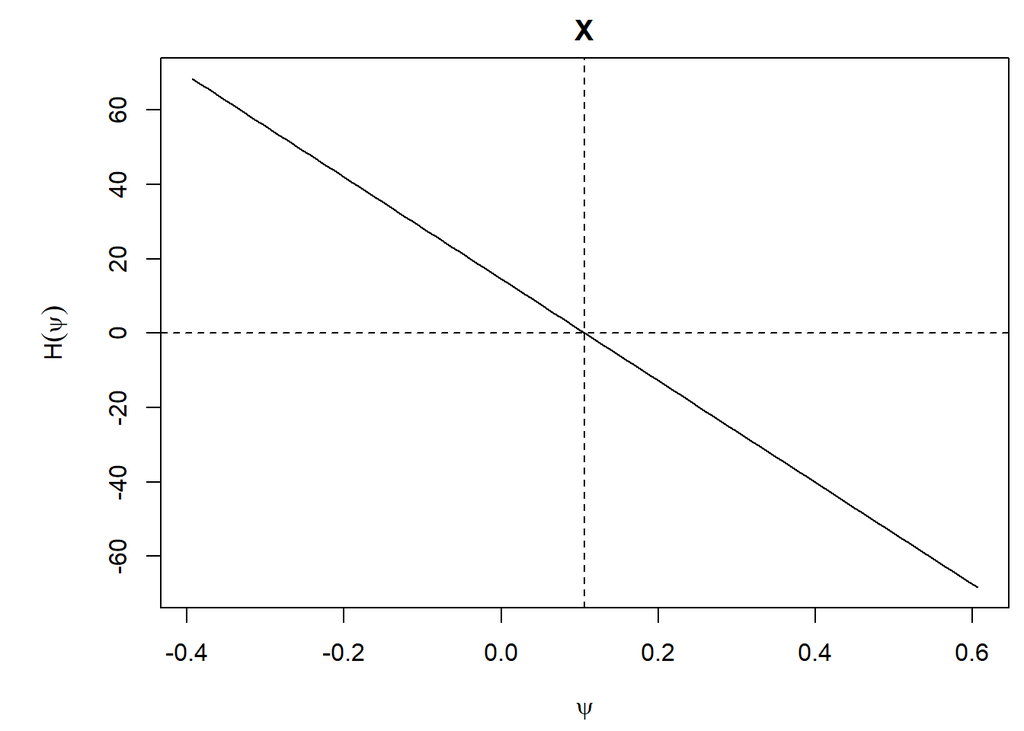

```r
# plot estimating function
estf1 <- estfun(fitIdentGest)
plot(estf1)
```

### Multiplication structural mean model: estimation of the causal risk ratio

```r
msmmMoments <- function(theta, x) {
  # extract variables from x
  Y <- x[, "Y"]
  X <- x[, "X"]
  Z1 <- x[, "Z"]
  # moments
  m1 <- (Y * exp(-1 * X * theta[2]) - theta[1])
  m2 <- (Y * exp(-1 * X * theta[2]) - theta[1]) * Z1
  return(cbind(m1, m2))
}

msmm <- gmm(msmmMoments, x = dat, t0 = c(0, 0), vcov = "iid")

# estimates
summary(msmm)
```

```
##
## Call:
## gmm(g = msmmMoments, x = dat, t0 = c(0, 0), vcov = "iid")
##
##
## Method:  twoStep
##
## Coefficients:
##           Estimate     Std. Error   t value      Pr(>|t|)
## Theta[1]   7.2784e-01   2.5893e-02   2.8110e+01  7.4591e-174
## Theta[2]   1.3107e-01   6.0307e-02   2.1733e+00   2.9754e-02
##
## J-Test: degrees of freedom is 0
##                 J-test                P-value
## Test E(g)=0:    1.73561467137432e-06  *******
##
## #############
## Information related to the numerical optimization
## Convergence code =  0
## Function eval. =  63
## Gradian eval. =  NA
```

```r
# causal risk ratio
exp(cbind(coef(msmm), confint(msmm)$test)[2, ])
```

```
##             0.025    0.975
## 1.140046 1.012952 1.283087
```

```r
# E[Y(0)]
cbind(coef(msmm), confint(msmm)$test)[1, ]
```

```
##               0.025     0.975
## 0.7278447 0.6770953 0.7785941
```

```r
# over-identification test
# specTest(msmm)
```

- Alternative syntax

```r
msmmAltMoments <- function(theta, x) {
  # extract variables from x
  Y <- x[, "Y"]
  X <- x[, "X"]
  Z1 <- x[, "Z"]
  # moments
  m1 <- (Y * exp(-theta[1] - X * theta[2]) - 1)
  m2 <- (Y * exp(-theta[1] - X * theta[2]) - 1) * Z1
  return(cbind(m1, m2))
}

msmm2 <- gmm(msmmAltMoments, x = dat, t0 = c(0, 0), vcov = "iid")

# model summary
summary(msmm2)
```

```
##
## Call:
## gmm(g = msmmAltMoments, x = dat, t0 = c(0, 0), vcov = "iid")
##
##
## Method:  twoStep
##
## Coefficients:
##           Estimate     Std. Error   t value      Pr(>|t|)
## Theta[1]  -3.1780e-01   3.5580e-02  -8.9320e+00   4.1831e-19
## Theta[2]   1.3136e-01   6.0323e-02   2.1776e+00   2.9433e-02
##
## J-Test: degrees of freedom is 0
##                 J-test                P-value
## Test E(g)=0:    2.10274737643992e-07  *******
##
## #############
## Information related to the numerical optimization
## Convergence code =  0
## Function eval. =  81
## Gradian eval. =  NA
```

```r
# exponentiate estimates
exp(cbind(coef(msmm2), confint(msmm2)$test))
```

```
##                        0.025     0.975
## Theta[1] 0.7277462 0.6787253 0.7803077
## Theta[2] 1.1403786 1.0132169 1.2834995
```

```r
# over-identification test
# specTest(msmm2)
```

#### Comparison fits

##### Two-stage residual inclusion

- TSRI with second stage log-binomial regression

```r
stage1 <- lm(X ~ Z, data = dat)
dat$res <- residuals(stage1)
stage2 <- logbin(Y ~ X + res, data = dat)

# model summary
summary(stage2)
```

```
##
## Call:
## logbin(formula = Y ~ X + res, data = dat)
##
## Deviance Residuals:
##     Min       1Q   Median       3Q      Max
## -2.0777   0.4955   0.5552   0.8283   0.8654
##
## Coefficients:
##             Estimate Std. Error z value Pr(>|z|)
## (Intercept) -0.33295    0.03447  -9.659  < 2e-16 ***
## X            0.16303    0.05803   2.810  0.00496 **
## res          0.05729    0.06685   0.857  0.39146
## ---
## Signif. codes:  0 '***' 0.001 '**' 0.01 '*' 0.05 '.' 0.1 ' ' 1
##
##     Null deviance: 1063.8  on 999  degrees of freedom
## Residual deviance: 1025.2  on 997  degrees of freedom
##
##   AIC: 1031.2
## AIC_c: 1031.2
##
## Number of iterations: 1855 (best: 872)
```

```r
# estimates and (perhaps slightly incorrect) CIs
exp(cbind(coef(stage2), confint(stage2)))
```

```
##                           2.5 %    97.5 %
## (Intercept) 0.7168028 0.6699745 0.7669041
## X           1.1770776 1.0505348 1.3188633
## res         1.0589655 0.9289143 1.2072242
```

```r
# checking CIs using bootstrap SEs

stat <- function(data, indices) {
  stage1 <- lm(X ~ Z, data = dat, subset = indices)
  dat$res[indices] <- residuals(stage1)
  stage2 <- logbin(Y ~ X + res, data = dat, subset = indices)
  return(coef(stage2))
}

bootrun <- boot(data = dat, statistic = stat, R = 100)
print(bootrun)
```

```
##
## ORDINARY NONPARAMETRIC BOOTSTRAP
##
##
## Call:
## boot(data = dat, statistic = stat, R = 100)
##
##
## Bootstrap Statistics :
##        original       bias    std. error
## t1* -0.33295454 -0.001990263  0.03339348
## t2*  0.16303479  0.004713716  0.06019355
## t3*  0.05729246 -0.006474751  0.07091351
```

```r
bci <- boot.ci(bootrun, type = "norm", index = 2)
exp(c(bci$t0, bci$normal[-1]))
```

```
##        X
## 1.177078 1.041169 1.318241
```

- TSRI with second stage Gamma regression with log-link: `geeM::geem()` fit

```r
stage1 <- lm(X ~ Z, data = dat)
dat$res <- residuals(stage1)
stage2 <- geem(Y ~ X + res, data = dat, family = Gamma(link = "log"))

# model summary
smry <- summary(stage2)
smry
```

```
##             Estimates Model SE Robust SE   wald       p
## (Intercept)   -0.3170  0.03377   0.03600 -8.806 0.00000
## X              0.1274  0.06370   0.06374  1.999 0.04561
## res            0.1130  0.07625   0.08128  1.391 0.16430
##
##  Estimated Correlation Parameter:  0
##  Correlation Structure:  independence
##  Est. Scale Parameter:  0.3039
##
##  Number of GEE iterations: 2
##  Number of Clusters:  1000    Maximum Cluster Size:  1
##  Number of observations with nonzero weight:  1000
```

```r
# estimates and (perhaps slightly incorrect) CIs
exp(cbind(coef(stage2),
  lci = coef(stage2) - 1.96 * smry$se.model,
  uci = coef(stage2) + 1.96 * smry$se.model
))
```

```
##                             lci       uci
## (Intercept) 0.7283198 0.6816757 0.7781554
## X           1.1358937 1.0025684 1.2869491
## res         1.1196749 0.9642351 1.3001724
```

- TSRI with second stage Gamma regression with log-link: `stats::glm()` fit

```r
stage1 <- lm(X ~ Z, data = dat)
dat$res <- residuals(stage1)
dat$Ystar <- dat$Y
dat <-
  dat %>% mutate(Ystar = recode(Y, `0` = 0.001, `1` = 1))
stage2glm <- glm(Ystar ~ X + res,
  data = dat,
  family = Gamma("log")
)

# model summary
smry <- summary(stage2glm)
smry
```

```
##
## Call:
## glm(formula = Ystar ~ X + res, family = Gamma("log"), data = dat)
##
## Deviance Residuals:
##     Min       1Q   Median       3Q      Max
## -3.4095   0.0980   0.1625   0.3565   0.4266
##
## Coefficients:
##             Estimate Std. Error t value Pr(>|t|)
## (Intercept) -0.31665    0.03372  -9.390   <2e-16 ***
## X            0.12727    0.06361   2.001   0.0457 *
## res          0.11286    0.07615   1.482   0.1386
## ---
## Signif. codes:  0 '***' 0.001 '**' 0.01 '*' 0.05 '.' 0.1 ' ' 1
##
## (Dispersion parameter for Gamma family taken to be 0.3030871)
##
##     Null deviance: 2588.0  on 999  degrees of freedom
## Residual deviance: 2576.9  on 997  degrees of freedom
## AIC: 1079.7
##
## Number of Fisher Scoring iterations: 9
```

```r
# causal risk ratio
exp(cbind(coef(stage2glm), confint.default(stage2glm)))
```

```
##                           2.5 %    97.5 %
## (Intercept) 0.7285888 0.6819900 0.7783716
## X           1.1357278 1.0025952 1.2865389
## res         1.1194762 0.9642634 1.2996728
```

- TSRI with second stage Gamma regression with log-link: `geepack::geeglm()` fit

```r
dat$id <- 1:nrow(dat)
stage2geeglm <- geeglm(Ystar ~ X + res,
  id = id, data = dat,
  family = Gamma("log")
)

# model summary
smry <- summary(stage2geeglm)
smry
```

```
##
## Call:
## geeglm(formula = Ystar ~ X + res, family = Gamma("log"), data = dat,
##     id = id)
##
##  Coefficients:
##             Estimate  Std.err   Wald Pr(>|W|)
## (Intercept) -0.31664  0.03595 77.578   <2e-16 ***
## X            0.12727  0.06366  3.997   0.0456 *
## res          0.11287  0.08116  1.934   0.1643
## ---
## Signif. codes:  0 '***' 0.001 '**' 0.01 '*' 0.05 '.' 0.1 ' ' 1
##
## Correlation structure = independence
## Estimated Scale Parameters:
##
##             Estimate Std.err
## (Intercept)   0.3022 0.02935
## Number of clusters:   1000  Maximum cluster size: 1
```

```r
# causal risk ratio
exp(cbind(coef(stage2geeglm), confint.default(stage2geeglm)))
```

```
##                     2.5 % 97.5 %
## (Intercept) 0.7286 0.6790 0.7818
## X           1.1357 1.0025 1.2866
## res         1.1195 0.9548 1.3125
```

- TSRI estimated using GMM with multiplicative error

```r
tsriLogMultMoments <- function(theta, x) {
  # extract variables from x
  Y <- x[, "Y"]
  X <- x[, "X"]
  Z1 <- x[, "Z"]
  # generate first stage residuals
  stage1 <- lm(X ~ Z1)
  res <- residuals(stage1)
  # moments
  a1 <- (X - theta[1] - Z1 * theta[2])
  a2 <- (X - theta[1] - Z1 * theta[2]) * Z1
  m1 <- (Y * exp(-theta[3] - X * theta[4] - theta[5] * (X - theta[1] - Z1 * theta[2])) - 1)
  m2 <- (Y * exp(-theta[3] - X * theta[4] - theta[5] * (X - theta[1] - Z1 * theta[2])) - 1) * X
  m3 <- (Y * exp(-theta[3] - X * theta[4] - theta[5] * (X - theta[1] - Z1 * theta[2])) - 1) * res
  return(cbind(a1, a2, m1, m2, m3))
}

# use initial values from chunk above = or glm Gamma log link code below
# stage1 <- lm(X ~ Z, data = dat)
# summary(stage1)
# res <- residuals(stage1)
# dat$Ystar[dat$Y == 0] <- dat$Y[dat$Y == 0] + 0.001
# stage2 <- glm(Ystar ~ X + res, data = dat, family = Gamma(link = "log"))
# summary(stage2)

# gmm fit
tsrigmmlog1 <- gmm(tsriLogMultMoments,
  x = dat,
  t0 = c(coef(stage1), coef(stage2)), vcov = "iid"
)

# estimates
summary(tsrigmmlog1)
```

```
##
## Call:
## gmm(g = tsriLogMultMoments, x = dat, t0 = c(coef(stage1), coef(stage2)),
##     vcov = "iid")
##
##
## Method:  twoStep
##
## Coefficients:
##              Estimate     Std. Error   t value      Pr(>|t|)
## (Intercept)   1.7647e-01   1.7169e-02   1.0278e+01   8.8297e-25
## Z             5.4740e-01   2.6249e-02   2.0854e+01   1.4138e-96
## (Intercept)  -3.1702e-01   3.5959e-02  -8.8159e+00   1.1868e-18
## X             1.2742e-01   6.4191e-02   1.9850e+00   4.7143e-02
## res           1.1304e-01   8.3917e-02   1.3470e+00   1.7797e-01
##
## J-Test: degrees of freedom is 0
##                 J-test                P-value
## Test E(g)=0:    1.93455308540168e-27  *******
##
## #############
## Information related to the numerical optimization
## Convergence code =  0
## Function eval. =  216
## Gradian eval. =  NA
```

```r
# causal risk ratio
exp(cbind(coef(tsrigmmlog1), confint(tsrigmmlog1)$test)[3:5, ])
```

```
##                     0.025  0.975
## (Intercept) 0.7283 0.6788 0.7815
## X           1.1359 1.0016 1.2882
## res         1.1197 0.9499 1.3198
```

- TSRI estimated using GMM with additive error

```r
tsriLogAddMoments <- function(theta, x) {
  # extract variables from x
  Y <- x[, "Y"]
  X <- x[, "X"]
  Z1 <- x[, "Z"]
  # generate first stage residuals
  stage1 <- lm(X ~ Z1)
  res <- residuals(stage1)
  # moments
  a1 <- (X - theta[1] - Z1 * theta[2])
  a2 <- (X - theta[1] - Z1 * theta[2]) * Z1
  m1 <- (Y - exp(theta[3] + X * theta[4] + theta[5] * (X - theta[1] - Z1 * theta[2])))
  m2 <- (Y - exp(theta[3] + X * theta[4] + theta[5] * (X - theta[1] - Z1 * theta[2]))) * X
  m3 <- (Y - exp(theta[3] + X * theta[4] + theta[5] * (X - theta[1] - Z1 * theta[2]))) * res
  return(cbind(a1, a2, m1, m2, m3))
}

# find initial values
stage1 <- lm(X ~ Z, data = dat)
summary(stage1)
```

```
##
## Call:
## lm(formula = X ~ Z, data = dat)
##
## Residuals:
##    Min     1Q Median     3Q    Max
## -0.724 -0.176 -0.176  0.276  0.824
##
## Coefficients:
##             Estimate Std. Error t value Pr(>|t|)
## (Intercept)   0.1765     0.0188    9.41   <2e-16 ***
## Z             0.5474     0.0263   20.79   <2e-16 ***
## ---
## Signif. codes:  0 '***' 0.001 '**' 0.01 '*' 0.05 '.' 0.1 ' ' 1
##
## Residual standard error: 0.416 on 998 degrees of freedom
## Multiple R-squared:  0.302,  Adjusted R-squared:  0.301
## F-statistic:  432 on 1 and 998 DF,  p-value: <2e-16
```

```r
res <- residuals(stage1)
stage2 <- logbin(Y ~ X + res, data = dat)
summary(stage2)
```

```
##
## Call:
## logbin(formula = Y ~ X + res, data = dat)
##
## Deviance Residuals:
##    Min      1Q  Median      3Q     Max
## -2.078   0.495   0.555   0.828   0.865
##
## Coefficients:
##             Estimate Std. Error z value Pr(>|z|)
## (Intercept)  -0.3330     0.0345   -9.66   <2e-16 ***
## X             0.1630     0.0580    2.81    0.005 **
## res           0.0573     0.0669    0.86    0.391
## ---
## Signif. codes:  0 '***' 0.001 '**' 0.01 '*' 0.05 '.' 0.1 ' ' 1
##
##     Null deviance: 1063.8  on 999  degrees of freedom
## Residual deviance: 1025.2  on 997  degrees of freedom
##
##   AIC: 1031
## AIC_c: 1031
##
## Number of iterations: 1855 (best: 872)
```

```r
# gmm fit
tsrigmmlog2 <- gmm(tsriLogAddMoments,
  x = dat,
  t0 = c(coef(stage1), coef(stage2)), vcov = "iid"
)

# estimates
summary(tsrigmmlog2)
```

```
##
## Call:
## gmm(g = tsriLogAddMoments, x = dat, t0 = c(coef(stage1), coef(stage2)),
##     vcov = "iid")
##
##
## Method:  twoStep
##
## Coefficients:
##              Estimate     Std. Error   t value      Pr(>|t|)
## (Intercept)   1.7648e-01   1.7169e-02   1.0279e+01   8.7991e-25
## Z             5.4738e-01   2.6249e-02   2.0853e+01   1.4272e-96
## (Intercept)  -3.2054e-01   3.5330e-02  -9.0727e+00   1.1610e-19
## X             1.3531e-01   6.1658e-02   2.1945e+00   2.8199e-02
## res           1.0014e-01   7.6665e-02   1.3062e+00   1.9150e-01
##
## J-Test: degrees of freedom is 0
##                 J-test                P-value
## Test E(g)=0:    1.52280712896901e-08  *******
##
## #############
## Information related to the numerical optimization
## Convergence code =  1
## Function eval. =  502
## Gradian eval. =  NA
```

```r
# causal risk ratio
exp(cbind(coef(tsrigmmlog2), confint(tsrigmmlog2)$test)[3:5, ])
```

```
##                     0.025  0.975
## (Intercept) 0.7258 0.6772 0.7778
## X           1.1449 1.0146 1.2920
## res         1.1053 0.9511 1.2845
```

##### G-estimation

```r
fitZ.L <- glm(Z ~ 1, data = dat)
fitY.LZX <- glm(Y ~ X + Z + X * Z, family = "binomial", data = dat)
summary(fitY.LZX)
```

```
##
## Call:
## glm(formula = Y ~ X + Z + X * Z, family = "binomial", data = dat)
##
## Deviance Residuals:
##    Min      1Q  Median      3Q     Max
## -1.997   0.541   0.541   0.808   0.928
##
## Coefficients:
##             Estimate Std. Error z value Pr(>|z|)
## (Intercept)    0.953      0.111    8.60   <2e-16 ***
## X              0.880      0.330    2.67   0.0077 **
## Z             -0.334      0.209   -1.60   0.1102
## X:Z            0.348      0.404    0.86   0.3894
## ---
## Signif. codes:  0 '***' 0.001 '**' 0.01 '*' 0.05 '.' 0.1 ' ' 1
##
## (Dispersion parameter for binomial family taken to be 1)
##
##     Null deviance: 1063.8  on 999  degrees of freedom
## Residual deviance: 1023.5  on 996  degrees of freedom
## AIC: 1031
##
## Number of Fisher Scoring iterations: 4
```

```r
fitLogGest <-
  ivglm(
    estmethod = "g",
    X = "X",
    fitZ.L = fitZ.L,
    fitY.LZX = fitY.LZX,
    data = dat,
    link = "log",
    Y = "Y"
  )

# model summary
summary(fitLogGest)
```

```
##
## Call:
## ivglm(estmethod = "g", X = "X", Y = "Y", fitZ.L = fitZ.L, fitY.LZX = fitY.LZX,
##     data = dat, link = "log")
##
## Coefficients:
##   Estimate Std. Error z value Pr(>|z|)
## X   0.1315     0.0604    2.18    0.029 *
## ---
## Signif. codes:  0 '***' 0.001 '**' 0.01 '*' 0.05 '.' 0.1 ' ' 1
```

```r
# estimates and CIs
exp(cbind(fitLogGest$est, confint(fitLogGest)))
```

```
##        2.5 % 97.5 %
## X 1.14 1.013  1.284
```

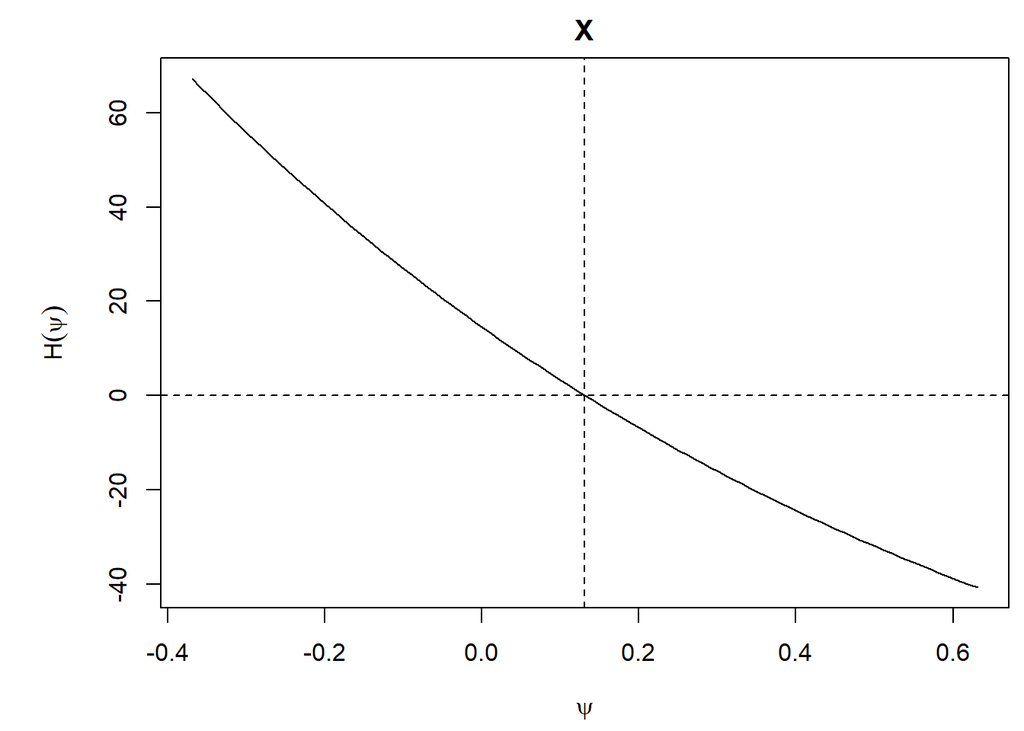

```r
# plot the estimating function
estf <- estfun(fitLogGest)
plot(estf)
```

##### G-estimation with initial values from TSRI

```r
stage1 <- lm(X ~ Z, data = dat)
dat$res <- residuals(stage1)
dat$Ystar <- dat$Y
dat <-
  dat %>% mutate(Ystar = recode(Y, `0` = 0.001, `1` = 1))
stage2glm <- glm(Ystar ~ X + res,
  data = dat,
  family = Gamma("log")
)
b0 <- coef(stage2glm)
b0
## (Intercept)           X         res
##     -0.3166      0.1273      0.1129

fitZ.L <- glm(Z ~ 1, data = dat)
fitY.LZX <- glm(Y ~ X + Z + X * Z, family = "binomial", data = dat)
summary(fitY.LZX)
```

```
##
## Call:
## glm(formula = Y ~ X + Z + X * Z, family = "binomial", data = dat)
##
## Deviance Residuals:
##    Min      1Q  Median      3Q     Max
## -1.997   0.541   0.541   0.808   0.928
##
## Coefficients:
##             Estimate Std. Error z value Pr(>|z|)
## (Intercept)    0.953      0.111    8.60   <2e-16 ***
## X              0.880      0.330    2.67   0.0077 **
## Z             -0.334      0.209   -1.60   0.1102
## X:Z            0.348      0.404    0.86   0.3894
## ---
## Signif. codes:  0 '***' 0.001 '**' 0.01 '*' 0.05 '.' 0.1 ' ' 1
##
## (Dispersion parameter for binomial family taken to be 1)
##
##     Null deviance: 1063.8  on 999  degrees of freedom
## Residual deviance: 1023.5  on 996  degrees of freedom
## AIC: 1031
##
## Number of Fisher Scoring iterations: 4
```

```r
fitLogGest <-
  ivglm(
    estmethod = "g",
    X = "X",
    fitZ.L = fitZ.L,
    fitY.LZX = fitY.LZX,
    data = dat,
    link = "log",
    Y = "Y",
    x = b0[2]
  )

# model summary
summary(fitLogGest)
```

```
##
## Call:
## ivglm(estmethod = "g", X = "X", Y = "Y", fitZ.L = fitZ.L, fitY.LZX = fitY.LZX,
##     data = dat, link = "log", x = b0[2])
##
## Coefficients:
##   Estimate Std. Error z value Pr(>|z|)
## X   0.1315     0.0604    2.18    0.029 *
## ---
## Signif. codes:  0 '***' 0.001 '**' 0.01 '*' 0.05 '.' 0.1 ' ' 1
```

```r
# estimates and CIs
exp(cbind(fitLogGest$est, confint(fitLogGest)))
```

```
##        2.5 % 97.5 %
## X 1.14 1.013  1.284
```

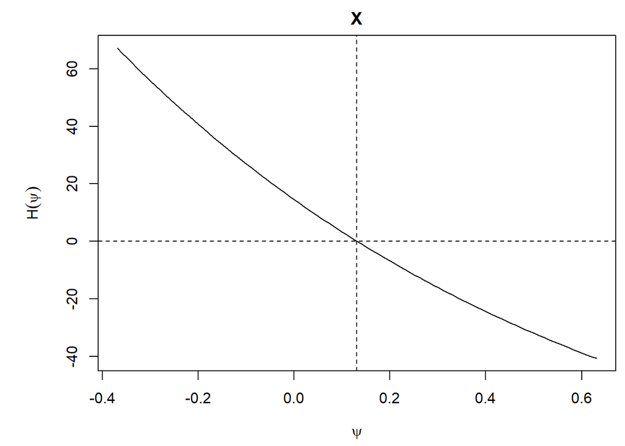

```r
# plot the estimating function
estf <- estfun(fitLogGest)
plot(estf)
```

##### TSLS using transformed variables

- Equations 24 and 25 of Clarke et al., i.e. outcome Y(1 - X) with exposure YX

```r
dat$yxm1 <- dat$Y * (1 - dat$X)
dat$yx <- dat$Y * dat$X

# first stage
stage1 <- lm(yx ~ Z, data = dat)
summary(stage1)
```

```
##
## Call:
## lm(formula = yx ~ Z, data = dat)
##
## Residuals:
##    Min     1Q Median     3Q    Max
## -0.625 -0.152 -0.152  0.375  0.848
##
## Coefficients:
##             Estimate Std. Error t value Pr(>|t|)
## (Intercept)   0.1521     0.0193     7.9  7.3e-15 ***
## Z             0.4731     0.0270    17.5  < 2e-16 ***
## ---
## Signif. codes:  0 '***' 0.001 '**' 0.01 '*' 0.05 '.' 0.1 ' ' 1
##
## Residual standard error: 0.427 on 998 degrees of freedom
## Multiple R-squared:  0.235,  Adjusted R-squared:  0.234
## F-statistic:  306 on 1 and 998 DF,  p-value: <2e-16
```

```r
# tsls fit
tslsmsmm <- ivreg(yxm1 ~ yx | Z, data = dat)
summary(tslsmsmm)
```

```
##
## Call:
## ivreg(formula = yxm1 ~ yx | Z, data = dat)
##
## Residuals:
##    Min     1Q Median     3Q    Max
## -0.728  0.149  0.149  0.272  0.272
##
## Coefficients:
##             Estimate Std. Error t value Pr(>|t|)
## (Intercept)   0.7277     0.0242    30.1   <2e-16 ***
## yx           -0.8768     0.0528   -16.6   <2e-16 ***
##
## Diagnostic tests:
##                  df1 df2 statistic p-value
## Weak instruments   1 998       306  <2e-16 ***
## Wu-Hausman         1 997        32   2e-08 ***
## Sargan             0  NA        NA      NA
## ---
## Signif. codes:  0 '***' 0.001 '**' 0.01 '*' 0.05 '.' 0.1 ' ' 1
##
## Residual standard error: 0.395 on 998 degrees of freedom
## Multiple R-Squared: 0.341,   Adjusted R-squared: 0.341
## Wald test:  276 on 1 and 998 DF,  p-value: <2e-16
```

```r
# causal risk ratio estimate
beta <- coef(tslsmsmm)
-1 / beta[2]
```

```
##   yx
## 1.14
```

```r
logcrr <- log(-1 / beta[2])

# delta-method SE
estvar <- vcov(tslsmsmm)
logcrrse <- deltamethod(~ log(-1 / x2), beta, estvar)
logcrrse
```

```
## [1] 0.06025
```

```r
# crr with 95% CI
res <- unname(c(-1 / beta[2], exp(logcrr - 1.96 * logcrrse), exp(logcrr + 1.96 * logcrrse)))
res
```

```
## [1] 1.140 1.013 1.283
```

```r
# baseline risk
cbind(coef(tslsmsmm), confint(tslsmsmm))[1, ]
```

```
##         2.5 % 97.5 %
## 0.7277 0.6803 0.7752
```

- TSLS using an alternative transformation, pages 109 and 110, i.e. outcome YX with exposure Y(1 - X)

```r
dat$yxm1 <- dat$Y * (1 - dat$X)

# first stage
stage1 <- lm(yxm1 ~ Z, data = dat)
summary(stage1)
```

```
##
## Call:
## lm(formula = yxm1 ~ Z, data = dat)
##
## Residuals:
##    Min     1Q Median     3Q    Max
## -0.594 -0.179 -0.179  0.406  0.821
##
## Coefficients:
##             Estimate Std. Error t value Pr(>|t|)
## (Intercept)   0.5943     0.0198    30.0   <2e-16 ***
## Z            -0.4148     0.0279   -14.9   <2e-16 ***
## ---
## Signif. codes:  0 '***' 0.001 '**' 0.01 '*' 0.05 '.' 0.1 ' ' 1
##
## Residual standard error: 0.44 on 998 degrees of freedom
## Multiple R-squared:  0.182,  Adjusted R-squared:  0.181
## F-statistic:  222 on 1 and 998 DF,  p-value: <2e-16
```

```r
# tsls fit
tslsmsmm2 <- ivreg(yx ~ yxm1 | Z, data = dat)
summary(tslsmsmm2)
```

```
##
## Call:
## ivreg(formula = yx ~ yxm1 | Z, data = dat)
##
## Residuals:
##    Min     1Q Median     3Q    Max
## -0.830  0.170  0.170  0.311  0.311
##
## Coefficients:
##             Estimate Std. Error t value Pr(>|t|)
## (Intercept)   0.8300     0.0300    27.7   <2e-16 ***
## yxm1         -1.1405     0.0687   -16.6   <2e-16 ***
##
## Diagnostic tests:
##                  df1 df2 statistic p-value
## Weak instruments   1 998       222  <2e-16 ***
## Wu-Hausman         1 997       103  <2e-16 ***
## Sargan             0  NA        NA      NA
## ---
## Signif. codes:  0 '***' 0.001 '**' 0.01 '*' 0.05 '.' 0.1 ' ' 1
##
## Residual standard error: 0.451 on 998 degrees of freedom
## Multiple R-Squared: 0.15,    Adjusted R-squared: 0.149
## Wald test:  276 on 1 and 998 DF,  p-value: <2e-16
```

```r
# causal risk ratio estimate
beta <- coef(tslsmsmm2)
-1 * beta[2]
## yxm1
## 1.14
logcrr <- log(-1 * beta[2])

# delta-method SE
estvar <- vcov(tslsmsmm2)
logcrrse <- deltamethod(~ log(-1 * x2), beta, estvar)
logcrrse
```

```
## [1] 0.06025
```

```r
# crr with 95% CI
res <- unname(c(-1 * beta[2], exp(logcrr - 1.96 * logcrrse), exp(logcrr + 1.96 * logcrrse)))
res
```

```
## [1] 1.140 1.013 1.283
```

##### MSMM with initial values

```r
stage1 <- lm(X ~ Z, data = dat)
dat$res <- residuals(stage1)
dat$Ystar <- dat$Y
dat <- dat %>%
  mutate(Ystar = recode(Y, `0` = 0.001, `1` = 1))
stage2glm <- glm(Ystar ~ X + res,
  data = dat,
  family = Gamma("log")
)

# model summary
smry <- summary(stage2glm)
smry
```

```
##
## Call:
## glm(formula = Ystar ~ X + res, family = Gamma("log"), data = dat)
##
## Deviance Residuals:
##    Min      1Q  Median      3Q     Max
## -3.410   0.098   0.162   0.357   0.427
##
## Coefficients:
##             Estimate Std. Error t value Pr(>|t|)
## (Intercept)  -0.3166     0.0337   -9.39   <2e-16 ***
## X             0.1273     0.0636    2.00    0.046 *
## res           0.1129     0.0762    1.48    0.139
## ---
## Signif. codes:  0 '***' 0.001 '**' 0.01 '*' 0.05 '.' 0.1 ' ' 1
##
## (Dispersion parameter for Gamma family taken to be 0.3031)
##
##     Null deviance: 2588.0  on 999  degrees of freedom
## Residual deviance: 2576.9  on 997  degrees of freedom
## AIC: 1080
##
## Number of Fisher Scoring iterations: 9
```

```r
b0 <- coef(stage2)
exp(b0[1])
## (Intercept)
##      0.7168
b0
## (Intercept)           X         res
##    -0.33295     0.16303     0.05729

msmmMoments <- function(theta, x) {
  # extract variables from x
  Y <- x[, "Y"]
  X <- x[, "X"]
  Z1 <- x[, "Z"]
  # moments
  m1 <- (Y * exp(-1 * X * theta[2]) - theta[1])
  m2 <- (Y * exp(-1 * X * theta[2]) - theta[1]) * Z1
  return(cbind(m1, m2))
}

msmm2 <- gmm(msmmMoments,
  x = dat,
  t0 = c(exp(b0[1]), b0[2]), vcov = "iid"
)

# estimates
summary(msmm2)
```

```
##
## Call:
## gmm(g = msmmMoments, x = dat, t0 = c(exp(b0[1]), b0[2]), vcov = "iid")
##
##
## Method:  twoStep
##
## Coefficients:
##              Estimate     Std. Error   t value      Pr(>|t|)
## (Intercept)   7.2771e-01   2.5892e-02   2.8106e+01  8.2923e-174
## X             1.3146e-01   6.0324e-02   2.1793e+00   2.9308e-02
##
## J-Test: degrees of freedom is 0
##                 J-test                P-value
## Test E(g)=0:    1.19881799682409e-11  *******
##
## #############
## Information related to the numerical optimization
## Convergence code =  0
## Function eval. =  71
## Gradian eval. =  NA
```

```r
# causal risk ratio
exp(cbind(coef(msmm2), confint(msmm2)$test)[2, ])
```

```
##       0.025 0.975
## 1.140 1.013 1.284
```

```r
# E[Y(0)]
cbind(coef(msmm2), confint(msmm2)$test)[1, ]
```

```
##         0.025  0.975
## 0.7277 0.6770 0.7785
```

##### Alt MSMM with initial values

```r
stage1 <- lm(X ~ Z, data = dat)
dat$res <- residuals(stage1)
dat$Ystar <- dat$Y
dat <- dat %>%
  mutate(Ystar = recode(Y, `0` = 0.001, `1` = 1))
stage2glm <- glm(Ystar ~ X + res,
  data = dat,
  family = Gamma("log")
)

# model summary
smry <- summary(stage2glm)
smry
```

```
##
## Call:
## glm(formula = Ystar ~ X + res, family = Gamma("log"), data = dat)
##
## Deviance Residuals:
##    Min      1Q  Median      3Q     Max
## -3.410   0.098   0.162   0.357   0.427
##
## Coefficients:
##             Estimate Std. Error t value Pr(>|t|)
## (Intercept)  -0.3166     0.0337   -9.39   <2e-16 ***
## X             0.1273     0.0636    2.00    0.046 *
## res           0.1129     0.0762    1.48    0.139
## ---
## Signif. codes:  0 '***' 0.001 '**' 0.01 '*' 0.05 '.' 0.1 ' ' 1
##
## (Dispersion parameter for Gamma family taken to be 0.3031)
##
##     Null deviance: 2588.0  on 999  degrees of freedom
## Residual deviance: 2576.9  on 997  degrees of freedom
## AIC: 1080
##
## Number of Fisher Scoring iterations: 9
```

```r
b0 <- coef(stage2)
b0
## (Intercept)           X         res
##    -0.33295     0.16303     0.05729

msmmAltMoments <- function(theta, x) {
  # extract variables from x
  Y <- x[, "Y"]
  X <- x[, "X"]
  Z1 <- x[, "Z"]
  # moments
  m1 <- (Y * exp(-theta[1] - X * theta[2]) - 1)
  m2 <- (Y * exp(-theta[1] - X * theta[2]) - 1) * Z1
  return(cbind(m1, m2))
}

msmm2 <- gmm(msmmAltMoments,
  x = dat,
  t0 = b0[1:2], vcov = "iid"
)

# model summary
summary(msmm2)
```

```
##
## Call:
## gmm(g = msmmAltMoments, x = dat, t0 = b0[1:2], vcov = "iid")
##
##
## Method:  twoStep
##
## Coefficients:
##              Estimate     Std. Error   t value      Pr(>|t|)
## (Intercept)  -3.1785e-01   3.5580e-02  -8.9335e+00   4.1257e-19
## X             1.3146e-01   6.0324e-02   2.1793e+00   2.9308e-02
##
## J-Test: degrees of freedom is 0
##                 J-test                P-value
## Test E(g)=0:    2.85062411031571e-11  *******
##
## #############
## Information related to the numerical optimization
## Convergence code =  0
## Function eval. =  69
## Gradian eval. =  NA
```

```r
# exponentiate estimates
exp(cbind(coef(msmm2), confint(msmm2)$test))
```

```
##                     0.025  0.975
## (Intercept) 0.7277 0.6787 0.7803
## X           1.1405 1.0133 1.2836
```

### Logistic structural mean model: estimation of the causal odds ratio

```r
# association model
am <- glm(Y ~ X + Z + X * Z, as.data.frame(dat), family = binomial)
print(summary(am))
```

```
##
## Call:
## glm(formula = Y ~ X + Z + X * Z, family = binomial, data = as.data.frame(dat))
##
## Deviance Residuals:
##    Min      1Q  Median      3Q     Max
## -1.997   0.541   0.541   0.808   0.928
##
## Coefficients:
##             Estimate Std. Error z value Pr(>|z|)
## (Intercept)    0.953      0.111    8.60   <2e-16 ***
## X              0.880      0.330    2.67   0.0077 **
## Z             -0.334      0.209   -1.60   0.1102
## X:Z            0.348      0.404    0.86   0.3894
## ---
## Signif. codes:  0 '***' 0.001 '**' 0.01 '*' 0.05 '.' 0.1 ' ' 1
##
## (Dispersion parameter for binomial family taken to be 1)
##
##     Null deviance: 1063.8  on 999  degrees of freedom
## Residual deviance: 1023.5  on 996  degrees of freedom
## AIC: 1031
##
## Number of Fisher Scoring iterations: 4
```

```r
amfit <- coef(am)
xblog <- qlogis(fitted.values(am))

# causal model with incorrect SEs
cmMoments <- function(theta, x) {
  # extract variables from x
  X <- x[, "X"]
  Z1 <- x[, "Z"]
  # moments
  c1 <- (plogis(xblog - theta[2] * X) - theta[1])
  c2 <- (plogis(xblog - theta[2] * X) - theta[1]) * Z1
  return(cbind(c1, c2))
}

cm <- gmm(cmMoments, x = dat, t0 = c(0, 0), vcov = "iid")
cmfit <- coef(cm)

lsmmMoments <- function(theta, x) {
  # extract variables from x
  Y <- x[, "Y"]
  X <- x[, "X"]
  Z1 <- x[, "Z"]
  XZ1 <- X * Z1
  # association model moments
  xb <- theta[1] + theta[2] * X + theta[3] * Z1 + theta[4] * XZ1
  a1 <- (Y - plogis(xb))
  a2 <- (Y - plogis(xb)) * X
  a3 <- (Y - plogis(xb)) * Z1
  a4 <- (Y - plogis(xb)) * XZ1
  # causal model moments
  c1 <- (plogis(xb - theta[6] * X) - theta[5])
  c2 <- (plogis(xb - theta[6] * X) - theta[5]) * Z1
  return(cbind(a1, a2, a3, a4, c1, c2))
}

lsmm <- gmm(lsmmMoments, x = dat, t0 = c(amfit, cmfit), vcov = "iid")

# model summary
print(summary(lsmm))
```

```
##
## Call:
## gmm(g = lsmmMoments, x = dat, t0 = c(amfit, cmfit), vcov = "iid")
##
##
## Method:  twoStep
##
## Coefficients:
##              Estimate      Std. Error    t value       Pr(>|t|)
## (Intercept)    9.5277e-01    1.1074e-01    8.6040e+00    7.6970e-18
## X              8.7989e-01    3.3006e-01    2.6658e+00    7.6796e-03
## Z             -3.3372e-01    2.0895e-01   -1.5971e+00    1.1024e-01
## X:Z            3.4793e-01    4.0434e-01    8.6047e-01    3.8953e-01
## Theta[1]       7.2744e-01    2.8789e-02    2.5268e+01   7.1530e-141
## Theta[2]       7.1068e-01    3.1132e-01    2.2828e+00    2.2444e-02
##
## J-Test: degrees of freedom is 0
##                 J-test                P-value
## Test E(g)=0:    4.35557892930723e-10  *******
##
## #############
## Information related to the numerical optimization
## Convergence code =  1
## Function eval. =  501
## Gradian eval. =  NA
```

```r
# E[Y(0)]
print(cbind(coef(lsmm), confint(lsmm)$test)[5])
```

```
## [1] 0.7274
```

```r
# exponentiate other estimates
print(exp(cbind(coef(lsmm), confint(lsmm)$test)[-5, ]))
```

```
##                     0.025 0.975
## (Intercept) 2.5929 2.0870 3.221
## X           2.4106 1.2624 4.603
## Z           0.7163 0.4756 1.079
## X:Z         1.4161 0.6411 3.128
## Theta[2]    2.0354 1.1057 3.747
```

```r
# over-identification test
# print(specTest(lsmm))
```

#### Comparison fits

##### Two-stage predictor substitution

```r
fitX.LZ <- glm(X ~ Z, family = "binomial", data = dat)
fitY.LX <- glm(Y ~ X, family = "binomial", data = dat)
fitLogisticTSPS <-
  ivglm(
    estmethod = "ts",
    fitX.LZ = fitX.LZ,
    fitY.LX = fitY.LX,
    data = dat,
    ctrl = FALSE
  )

# model summary
summary(fitLogisticTSPS)
```

```
##
## Call:
## ivglm(estmethod = "ts", fitX.LZ = fitX.LZ, fitY.LX = fitY.LX,
##     data = dat, ctrl = FALSE)
##
## Coefficients:
##             Estimate Std. Error z value Pr(>|z|)
## (Intercept)    0.971      0.140    6.91  4.7e-12 ***
## X              0.615      0.275    2.24    0.025 *
## ---
## Signif. codes:  0 '***' 0.001 '**' 0.01 '*' 0.05 '.' 0.1 ' ' 1
```

```r
# estimates and CIs
exp(cbind(fitLogisticTSPS$est, confint(fitLogisticTSPS)))
```

```
##                   2.5 % 97.5 %
## (Intercept) 2.641 2.006  3.479
## X           1.849 1.079  3.168
```

- TSPS estimated using GMM

```r
tspsLogitMoments <- function(theta, x) {
  # extract variables from x
  Y <- x[, "Y"]
  X <- x[, "X"]
  Z1 <- x[, "Z"]
  # generate first stage residuals
  stage1 <- lm(X ~ Z1)
  xhat <- fitted.values(stage1)
  # moments
  a1 <- (X - theta[1] - Z1 * theta[2])
  a2 <- (X - theta[1] - Z1 * theta[2]) * Z1
  m1 <- (Y - plogis(theta[3] + (theta[1] + theta[2] * Z1) * theta[4]))
  m2 <- (Y - plogis(theta[3] + (theta[1] + theta[2] * Z1) * theta[4])) * xhat
  return(cbind(a1, a2, m1, m2))
}

# find initial values
stage1 <- lm(X ~ Z, data = dat)
xhat <- fitted.values(stage1)
summary(stage1)
```

```
##
## Call:
## lm(formula = X ~ Z, data = dat)
##
## Residuals:
##    Min     1Q Median     3Q    Max
## -0.724 -0.176 -0.176  0.276  0.824
##
## Coefficients:
##             Estimate Std. Error t value Pr(>|t|)
## (Intercept)   0.1765     0.0188    9.41   <2e-16 ***
## Z             0.5474     0.0263   20.79   <2e-16 ***
## ---
## Signif. codes:  0 '***' 0.001 '**' 0.01 '*' 0.05 '.' 0.1 ' ' 1
##
## Residual standard error: 0.416 on 998 degrees of freedom
## Multiple R-squared:  0.302,  Adjusted R-squared:  0.301
## F-statistic:  432 on 1 and 998 DF,  p-value: <2e-16
```

```r
stage2 <- glm(Y ~ xhat, data = dat, family = binomial)
summary(stage2)
```

```
##
## Call:
## glm(formula = Y ~ xhat, family = binomial, data = dat)
##
## Deviance Residuals:
##    Min      1Q  Median      3Q     Max
## -1.807   0.659   0.659   0.765   0.765
##
## Coefficients:
##             Estimate Std. Error z value Pr(>|z|)
## (Intercept)    0.971      0.142    6.86  6.9e-12 ***
## xhat           0.615      0.279    2.21    0.027 *
## ---
## Signif. codes:  0 '***' 0.001 '**' 0.01 '*' 0.05 '.' 0.1 ' ' 1
##
## (Dispersion parameter for binomial family taken to be 1)
##
##     Null deviance: 1063.8  on 999  degrees of freedom
## Residual deviance: 1059.0  on 998  degrees of freedom
## AIC: 1063
##
## Number of Fisher Scoring iterations: 4
```

```r
# gmm fit
tspsgmmlogit <- gmm(tspsLogitMoments, x = dat, t0 = c(coef(stage1), coef(stage2)), vcov = "iid")

# estimates
summary(tspsgmmlogit)
```

```
##
## Call:
## gmm(g = tspsLogitMoments, x = dat, t0 = c(coef(stage1), coef(stage2)),
##     vcov = "iid")
##
##
## Method:  twoStep
##
## Coefficients:
##              Estimate    Std. Error  t value     Pr(>|t|)
## (Intercept)  1.7647e-01  1.7169e-02  1.0278e+01  8.8297e-25
## Z            5.4740e-01  2.6249e-02  2.0854e+01  1.4138e-96
## (Intercept)  9.7133e-01  1.4042e-01  6.9173e+00  4.6027e-12
## xhat         6.1451e-01  2.7464e-01  2.2375e+00  2.5256e-02
##
## J-Test: degrees of freedom is 0
##                 J-test                P-value
## Test E(g)=0:    8.88497490724335e-23  *******
##
## #############
## Information related to the numerical optimization
## Convergence code =  0
## Function eval. =  169
## Gradian eval. =  NA
```

```r
# baseline odds and causal odds ratio
exp(cbind(coef(tspsgmmlogit), confint(tspsgmmlogit)$test)[3:4, ])
```

```
##                   0.025 0.975
## (Intercept) 2.641 2.006 3.478
## xhat        1.849 1.079 3.167
```

##### Two-stage residual inclusion

```r
fitLogisticTSRI <-
  ivglm(
    estmethod = "ts",
    fitX.LZ = fitX.LZ,
    fitY.LX = fitY.LX,
    data = dat,
    ctrl = TRUE
  )

# model summary
summary(fitLogisticTSRI)
```

```
##
## Call:
## ivglm(estmethod = "ts", fitX.LZ = fitX.LZ, fitY.LX = fitY.LX,
##     data = dat, ctrl = TRUE)
##
## Coefficients:
##             Estimate Std. Error z value Pr(>|z|)
## (Intercept)    1.007      0.145    6.95  3.7e-12 ***
## X              0.670      0.285    2.36    0.018 *
## R              1.117      0.200    5.60  2.2e-08 ***
## ---
## Signif. codes:  0 '***' 0.001 '**' 0.01 '*' 0.05 '.' 0.1 ' ' 1
```

```r
# estimates and CIs
exp(cbind(fitLogisticTSRI$est, confint(fitLogisticTSRI)))
```

```
##                   2.5 % 97.5 %
## (Intercept) 2.737 2.060  3.636
## X           1.955 1.119  3.415
## R           3.056 2.067  4.518
```

- TSRI estimated using GMM

```r
tsriLogitMoments <- function(theta, x) {
  # extract variables from x
  Y <- x[, "Y"]
  X <- x[, "X"]
  Z1 <- x[, "Z"]
  # generate first stage residuals
  stage1 <- lm(X ~ Z1)
  res <- residuals(stage1)
  # moments
  a1 <- (X - theta[1] - Z1 * theta[2])
  a2 <- (X - theta[1] - Z1 * theta[2]) * Z1
  m1 <- (Y - plogis(theta[3] + X * theta[4] + theta[5] * (X - theta[1] - Z1 * theta[2])))
  m2 <- (Y - plogis(theta[3] + X * theta[4] + theta[5] * (X - theta[1] - Z1 * theta[2]))) * X
  m3 <- (Y - plogis(theta[3] + X * theta[4] + theta[5] * (X - theta[1] - Z1 * theta[2]))) * res
  return(cbind(a1, a2, m1, m2, m3))
}

# obtain starting values for gmm
stage1 <- lm(X ~ Z)
res <- residuals(stage1)
coef(stage1)
## (Intercept)           Z
##      0.1765      0.5474
stage2 <- glm(Y ~ X + res, family = binomial)
coef(stage2)
## (Intercept)           X         res
##      1.0068      0.6705      0.4466

# gmm fit
tsrigmmlogit <- gmm(tsriLogitMoments, x = dat, t0 = c(coef(stage1), coef(stage2)), vcov = "iid")

# estimates
summary(tsrigmmlogit)
```

```
##
## Call:
## gmm(g = tsriLogitMoments, x = dat, t0 = c(coef(stage1), coef(stage2)),
##     vcov = "iid")
##
##
## Method:  twoStep
##
## Coefficients:
##              Estimate    Std. Error  t value     Pr(>|t|)
## (Intercept)  1.7647e-01  1.7169e-02  1.0278e+01  8.8297e-25
## Z            5.4740e-01  2.6249e-02  2.0854e+01  1.4138e-96
## (Intercept)  1.0068e+00  1.4482e-01  6.9520e+00  3.6002e-12
## X            6.7047e-01  2.8436e-01  2.3578e+00  1.8382e-02
## res          4.4657e-01  3.4141e-01  1.3080e+00  1.9086e-01
##
## J-Test: degrees of freedom is 0
##                 J-test                P-value
## Test E(g)=0:    4.36189434867539e-23  *******
##
## #############
## Information related to the numerical optimization
## Convergence code =  0
## Function eval. =  208
## Gradian eval. =  NA
```

```r
# causal odds ratio
exp(cbind(coef(tsrigmmlogit), confint(tsrigmmlogit)$test)[3:5, ])
```

```
##                    0.025 0.975
## (Intercept) 2.737 2.0605 3.635
## X           1.955 1.1198 3.414
## res         1.563 0.8005 3.052
```

##### G-estimation

```r
fitZ.L <- glm(Z ~ 1, data = dat)
fitY.LZX <- glm(Y ~ X + Z + X * Z, family = "binomial", data = dat)
fitLogisticGest <-
  ivglm(
    estmethod = "g",
    X = "X",
    fitZ.L = fitZ.L,
    fitY.LZX = fitY.LZX,
    data = dat,
    link = "logit"
  )

# model summary
summary(fitLogisticGest)
```

```
##
## Call:
## ivglm(estmethod = "g", X = "X", fitZ.L = fitZ.L, fitY.LZX = fitY.LZX,
##     data = dat, link = "logit")
##
## Coefficients:
##   Estimate Std. Error z value Pr(>|z|)
## X    0.711      0.311    2.28    0.023 *
## ---
## Signif. codes:  0 '***' 0.001 '**' 0.01 '*' 0.05 '.' 0.1 ' ' 1
```

```r
# estimates and CIs
exp(cbind(fitLogisticGest$est, confint(fitLogisticGest)))
```

```
##         2.5 % 97.5 %
## X 2.035 1.105  3.748
```

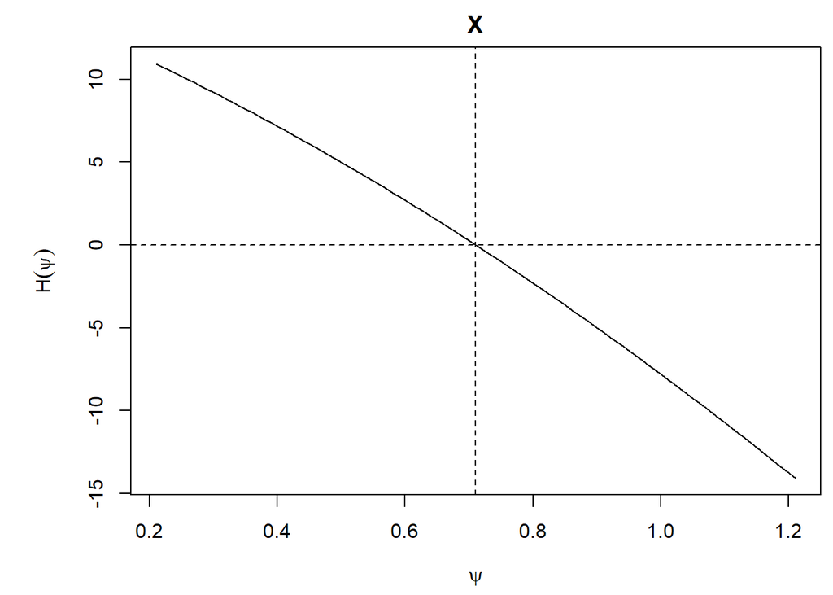

```r
# plot estimating function
estf3 <- estfun(fitLogisticGest)
plot(estf3)
```